# 1. Load MNIST Dataset

It consists of handwritten digits, divided into $60000$ training images and $10000$ test images. All images are gray-scale (one channel with pixel intensities varying from 0 to 255) and have size $28 \times 28$. There are 10 classes, corresponding to digits 0 to 9.

The dataset is available in many places. Here we will use the one available with Keras [1]. More information on MNIST can be found at the [oficial site](http://yann.lecun.com/exdb/mnist/).

[1]: François Chollet and others, Keras, https://keras.io, 2015

```python
from tensorflow.keras.datasets import mnist

(X_train_all, y_train_all), (X_test_all, y_test) = mnist.load_data()
```

# 2. Process "Raw" Features

This time we will use pixel intensities as features. The images must be flattened to vector format and the feature values must be scaled to the range [0,1] (as float).

```python
import numpy as np

#Flatten to vector - reshape

X_train_flat = X_train_all.reshape(60000,784)
X_test_flat = X_test_all.reshape(10000,784)


#Scale train data to range [0,1]
X_train_scale = X_train_flat.astype('float32') / 255
X_test_scale = X_test_flat.astype('float32') / 255

X_test = X_test_scale
```

# 3. Create Reduced Training Set

To reduce computation time, let us create a reduced training set by randomly selecting 2000 examples of each class from the original training set. Thus our effective training set (reduced training set) will consist of 20000 examples.

```python
import numpy as np
from random import seed

unique = np.unique(y_train_all) #array of unique class values (of course we know that it's 0-9)

#create subsets for each class (ten in total)
X_train_subsets = np.array([X_train_scale[y_train_all == number] for number in unique])
y_train_subsets = np.array([y_train_all[y_train_all == number] for number in unique])

#sample 2000 examples from each class
indices = np.array([np.random.choice(X_train_subsets[number].shape[0], 2000, replace=False)
                   for number in unique]) #get sample indexes

X_train = np.array([X_train_subsets[number][indices[number]] for number in unique])
y_train = np.array([y_train_subsets[number][indices[number]] for number in unique])

#join subsets - reshape
X_train = X_train.reshape(20000,784)
y_train = y_train.reshape(20000,)

#Shuffle samples in training set
rng_state = np.random.get_state()
np.random.shuffle(X_train)
np.random.set_state(rng_state)
np.random.shuffle(y_train)
```

### Print Values

Print the following properties of the sets X_train, y_train, X_test, y_test:

- dtype
- shape
- minimum value
- maximum value

```python
import numpy as np

#dtype
print("dtypes:")
print("X_train:", type(X_train))
print("y_train:", type(y_train))
print("X_test:", type(X_test))
print("y_test:", type(y_test), "\n")

#shape
print("shapes:")
print("X_train:", X_train.shape)
print("y_train:", y_train.shape)
print("X_test:", X_test.shape)
print("y_test:", y_test.shape, "\n")

#minimum value
print("Minimum value X_train:", np.amin(X_train))
print("Minimum value X_test:", np.amin(X_test), "\n")

#maximum value
print("Maximum value X_train:", np.amax(X_train))
print("Maximum value X_test:", np.amax(X_test), "\n")
```

```
dtypes:
X_train: <class 'numpy.ndarray'>
y_train: <class 'numpy.ndarray'>
X_test: <class 'numpy.ndarray'>
y_test: <class 'numpy.ndarray'>

shapes:
X_train: (20000, 784)
y_train: (20000,)
X_test: (10000, 784)
y_test: (10000,)

Minimum value X_train: 0.0
Minimum value X_test: 0.0

Maximum value X_train: 1.0
Maximum value X_test: 1.0
```

### Example Images

At the end of this part, randomly choose at least 3 examples from the set (X_train, y_train) and display the images as well as the respective class labels.

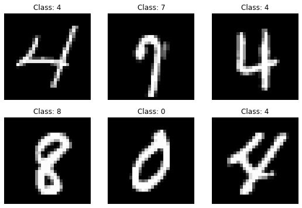

```python
import matplotlib.pyplot as plt
%matplotlib inline

fig, ax = plt.subplots(2, 3, figsize = (9, 6))

for i in range(6):
    index = np.random.choice(2000)
    ax[i//3, i%3].imshow(X_train[index].reshape(28,28,), cmap='gray')
    ax[i//3, i%3].axis('off')
    ax[i//3, i%3].set_title("Class: %d"%y_train[index])

plt.show()
```

# 3. Model Selection

A model must be chosen based on 5-fold cross-validation applied on the reduced training set; use stratified cross-validation. All models must be trained on the same set of folds. You should consider at least 3 different models (architectures). Among them, the one at https://github.com/fchollet/deep-learning-with-python-notebooks/blob/master/2.1-a-first-look-at-a-neural-network.ipynb (same architecture and whenever possible, same hyperparameters) is mandatory. The others may be networks with variations in architecture and/or hyperparameters. Fix the number of epochs for training (you may plot the learning curve to see how it is behaving and based on that choose the number of appropriate epochs).

### 3.1 Choose appropriate number of epochs

```
Training set score: 0.975300
Training set loss: 0.099576
```

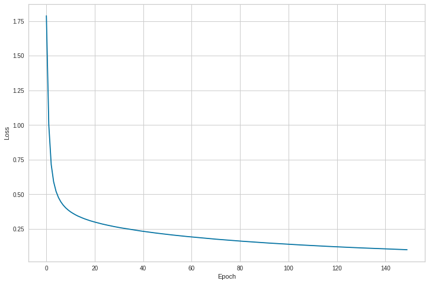

```python
from sklearn.neural_network import MLPClassifier #multi-layer perceptron classifier
import matplotlib.pyplot as plt

#Initializing the MLPClassifiers
#sgd solver: stochastic gradient descent
#default learning rate is 0.001
#max_iter: For stochastic solvers (‘sgd’, ‘adam’), note that this determines the number of epochs
#(how many times each data point will be used), not the number of gradient steps.
#verbose: Whether to print progress messages to stdout.


#Choose best number of epochs
mlp1 = MLPClassifier(hidden_layer_sizes=(512,), max_iter = 150, activation = 'relu',
                    solver='sgd',batch_size = 128, random_state=1, verbose = 0)

mlp1.fit(X_train, y_train)


print("Training set score: %f" % mlp1.score(X_train, y_train))
print("Training set loss: %f" % mlp1.loss_)

#Plot loss curve
plt.figure(figsize = (12, 8))
plt.plot(mlp1.loss_curve_)
plt.xlabel('Epoch')
plt.ylabel('Loss')
plt.show()
```

## Number of epochs

The loss seems to continue decaying as I increase the number of epochs. But, due to long run time, I'm going to used 50 epochs (which still takes some time to run).

### 3.2 Model selection

```python
from sklearn.neural_network import MLPClassifier #multi-layer perceptron classifier
from sklearn.model_selection import StratifiedKFold
from sklearn.model_selection import cross_validate
from sklearn.exceptions import ConvergenceWarning
import numpy as np

#Initializing the MLPClassifiers
#sgd solver: stochastic gradient descent
#default learning rate is 0.001
#max_iter: For stochastic solvers (‘sgd’, ‘adam’), note that this determines the number of epochs
#(how many times each data point will be used), not the number of gradient steps.
#verbose: Whether to print progress messages to stdout.

#3 different models
models = [
            ("mlp1", MLPClassifier(hidden_layer_sizes=(512,), max_iter=50, activation = 'relu',
                    solver='sgd', batch_size = 128, random_state=1, verbose = 0)),
            ("mlp2", MLPClassifier(hidden_layer_sizes=(512,), max_iter=50, activation = 'logistic',
                    solver='sgd', batch_size = 128, random_state=1, verbose = 0)), #logistic activation
            ("mlp3", MLPClassifier(hidden_layer_sizes=(512,), max_iter=50, learning_rate_init = 0.01,
                    activation = 'relu', solver='sgd', batch_size = 128, random_state=1, verbose = 0)), #larger learning rate
            ("mlp4", MLPClassifier(hidden_layer_sizes=(512, 200,), max_iter=50, activation = 'relu',
                    solver='sgd', batch_size = 128, random_state=1, verbose = 0)) #another hidden layer

        ]


# 5-fold cross-validation for each model
for name, model in models:
        warnings.filterwarnings("ignore", category=ConvergenceWarning, module="sklearn")
        kfold = StratifiedKFold(n_splits=5, shuffle = True, random_state = 1) #same at each iteration
        cv_results = cross_validate(model, X_train, y_train, cv=kfold, scoring="accuracy")
        print(name, "Accuracy of Folds:", cv_results['test_score'])
        print(name, "Final (mean) Score:", np.mean(cv_results['test_score']), "\n")
```

```
mlp1 Accuracy of Folds: [0.92375 0.92675 0.92375 0.9175  0.928  ]
mlp1 Final (mean) Score: 0.9239499999999999

mlp2 Accuracy of Folds: [0.8785  0.872   0.8795  0.872   0.87075]
mlp2 Final (mean) Score: 0.8745499999999999

mlp3 Accuracy of Folds: [0.96425 0.9655  0.965   0.95875 0.9635 ]
mlp3 Final (mean) Score: 0.9634

mlp4 Accuracy of Folds: [0.93875 0.942   0.93975 0.932   0.9405 ]
mlp4 Final (mean) Score: 0.9385999999999999
```

## Selected Model

mlp3 (implemented with larger learning rate) has better accuracy than the other models. I'll be doing the last part of the exercise with this model.

# 4. Selected Model Evaluation

After model selection, train again the selected model, now using the entire reduced training set, to get the final model. (Note that here there is no validation step) Test the final model on the test set.

- Plot the learning curve of the selected model (when retraining on X train).
- Print the number of examples of each class in the test set.
- Plot the confusion matrix with respect to the test set.

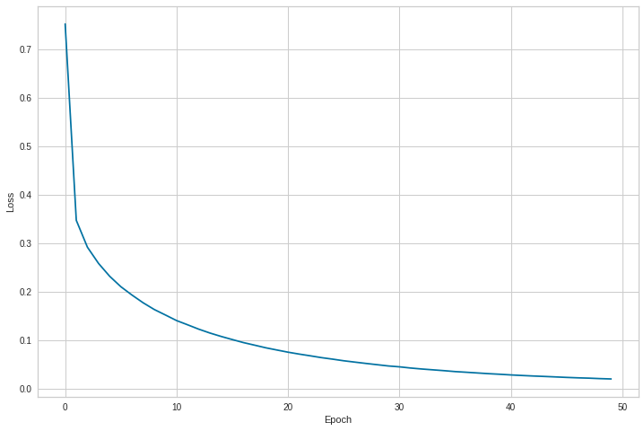

```
Class count in test set:

class 0 : 980
class 1 : 1135
class 2 : 1032
class 3 : 1010
class 4 : 982
class 5 : 892
class 6 : 958
class 7 : 1028
class 8 : 974
class 9 : 1009


Classification Report:

               precision    recall  f1-score   support

     class 0       0.97      0.99      0.98       980
     class 1       0.99      0.99      0.99      1135
     class 2       0.97      0.97      0.97      1032
     class 3       0.97      0.98      0.97      1010
     class 4       0.97      0.97      0.97       982
     class 5       0.97      0.97      0.97       892
     class 6       0.97      0.97      0.97       958
     class 7       0.97      0.96      0.97      1028
     class 8       0.97      0.96      0.97       974
     class 9       0.96      0.95      0.96      1009

    accuracy                           0.97     10000
   macro avg       0.97      0.97      0.97     10000
weighted avg       0.97      0.97      0.97     10000


Confusion matrix:

 [[ 966    0    2    2    0    0    6    1    2    1]
 [   0 1119    3    1    0    1    5    1    5    0]
 [   6    1  996    4    5    0    4    9    6    1]
 [   0    0    4  989    0    5    0    4    4    4]
 [   2    0    4    0  955    1    4    1    1   14]
 [   6    1    0    6    2  861    7    1    6    2]
 [   6    4    2    1    6    7  931    0    1    0]
 [   1    5   14    5    0    0    0  992    1   10]
 [   5    1    3    7    3    7    3    7  935    3]
 [   4    4    2    9   17    3    1    8    0  961]]
```

```python
from sklearn.neural_network import MLPClassifier #multi-layer perceptron classifier
from sklearn.exceptions import ConvergenceWarning
import numpy as np
from sklearn.metrics import classification_report
from sklearn.metrics import confusion_matrix

#selected model
mlp = MLPClassifier(hidden_layer_sizes=(512,), max_iter=50, learning_rate_init = 0.01,
                    activation = 'relu', solver='sgd', batch_size = 128, random_state=1, verbose = 0)

warnings.filterwarnings("ignore", category=ConvergenceWarning, module="sklearn")
mlp.fit(X_train, y_train)

#Plot loss curve (retraining on X_train)
plt.figure(figsize = (12, 8))
plt.plot(mlp.loss_curve_)
plt.xlabel('Epoch')
plt.ylabel('Loss')
plt.show()

#print number of examples of each class in the test set
target_names = ["class 0", "class 1", "class 2", "class 3", "class 4", "class 5", "class 6", "class 7", "class 8", "class 9"]
unique, counts = np.unique(y_test, return_counts=True)

print("Class count in test set: \n")
for number in range(10):
    print(target_names[number],":", counts[number])
print("\n")

#Plot the confusion matrix with respect to the test set
y_pred = mlp.predict(X_test) #predict classes


print("Classification Report: \n \n",classification_report(y_test, y_pred, target_names=target_names), "\n")
print("Confusion matrix: \n \n",confusion_matrix(y_test, y_pred, labels=range(10)))
```

The selected model has an accuracy of 97% on the test data.